# Work

jmfti

2022-09-10

# Cap1 - Linear regression

Methods to fit a linear function over some parameters (w) against a test data
$$y = \sum_{i=1}^n{w_{i} x_{i}} +
w_0$$
Given vector $t$ of observations, we need to find a function $y(x, w) = w_0 + w_1 x_1 + ... + w_n x_n$
$$\begin{align} y(\textbf{x},\textbf{w}) = \sum _{j=0} ^{M} \left (
w_j\phi_j(\textbf{x}) \right ) =
\textbf{w}^T \Phi
\end{align}$$
So that $\textbf{w} = (w_0, ..., w_M-1)^T$ y $\Phi = (\phi_0, ..., \phi_D)^T$. $\Phi(\textbf{x})$ is a matrix, with as many columns as base functions has $\phi(x_i)$

Assuming a cuadratic error function, the optimal prediction for a new value of x will come determined by the conditional mean
$$\begin{align}
E[t\mid \textbf{x}] = \int{ t p(t\mid \textbf{x}) dt =
y(\textbf{x},\textbf{w}) }
\end{align}$$
So assuming a target vector $\textbf{t} = (t_1, ..., t_n)$ and a set of variables $\textbf{X}=\{x_1, x_2,...,x_n\}$, Assuming independence of all events, the likelihood function is (according to Bishop) the product of all the observations
$$\begin{align} p(\textbf{t} \mid \textbf{X}, \textbf{w}, \lambda) = p(t_1
\mid \textbf{x}_1, \textbf{w}, \lambda) p(t_2 \mid \textbf{x}_2,
\textbf{w}, \lambda) ... p(t_n \mid \textbf{x}_n, w, \lambda)
\end{align}$$
$$\begin{align} p(\textbf{t} \mid \textbf{X}, \textbf{w}, \lambda ) =
\prod _{n=1} ^N N(t_n \mid \textbf{w}^T\phi(\textbf{x}_n), \lambda^{-1}
)
\end{align}$$
Taking the log likelihood product turns into a sum
$$\begin{align}
\ln p(\textbf{t} \mid \textbf{X}, \textbf{w}, \lambda) &= \sum
_{n=1} ^N \ln N(t_n \mid w^T, \phi(x_n), \lambda^{-1}) \\
&= \dfrac{N}{2} \ln \lambda - \dfrac{N}{2} \ln (2\pi) - \lambda
\left ( \dfrac{1}{2} \sum _{n=1} ^N \left [ t_n - w^T \phi(x_n) \right
]^2 \right )
\end{align}$$
Now to find the best matching values for that makes more likely the vector t we find the gradient of the function and set to 0. We derive the function in respect to probability, so when we set to 0, we are trying find a w vector that maximizes the probability
$$\begin{align}
\nabla \ln p(\textbf{t} \mid \textbf{X}, \textbf{w}, \lambda) = \sum
_{n=1} ^N \left ( t_n - \textbf{w}^T \phi(x_n) \right )\phi(x_n)^T
\end{align}$$

so

$$\begin{align}
\textbf{w} &= ( \Phi^T \Phi)^{-1} \Phi^T \textbf{t}
\end{align}$$
That gives us the parameters for the model

```r
#library(MASS)
#library(ISLR2)
head(Boston)
```

```
##      crim zn indus chas   nox    rm  age    dis rad tax ptratio lstat medv
## 1 0.00632 18  2.31    0 0.538 6.575 65.2 4.0900   1 296    15.3  4.98 24.0
## 2 0.02731  0  7.07    0 0.469 6.421 78.9 4.9671   2 242    17.8  9.14 21.6
## 3 0.02729  0  7.07    0 0.469 7.185 61.1 4.9671   2 242    17.8  4.03 34.7
## 4 0.03237  0  2.18    0 0.458 6.998 45.8 6.0622   3 222    18.7  2.94 33.4
## 5 0.06905  0  2.18    0 0.458 7.147 54.2 6.0622   3 222    18.7  5.33 36.2
## 6 0.02985  0  2.18    0 0.458 6.430 58.7 6.0622   3 222    18.7  5.21 28.7
```

# Simple Linear regression

```r
lm.fit <- lm(medv ~ lstat, data=Boston)
lm.fit
```

```
##
## Call:
## lm(formula = medv ~ lstat, data = Boston)
##
## Coefficients:
## (Intercept)        lstat
##       34.55        -0.95
```

```r
summary(lm.fit)
```

```
##
## Call:
## lm(formula = medv ~ lstat, data = Boston)
##
## Residuals:
##     Min      1Q  Median      3Q     Max
## -15.168  -3.990  -1.318   2.034  24.500
##
## Coefficients:
##             Estimate Std. Error t value Pr(>|t|)
## (Intercept) 34.55384    0.56263   61.41   <2e-16 ***
## lstat       -0.95005    0.03873  -24.53   <2e-16 ***
## ---
## Signif. codes:  0 '***' 0.001 '**' 0.01 '*' 0.05 '.' 0.1 ' ' 1
##
## Residual standard error: 6.216 on 504 degrees of freedom
## Multiple R-squared:  0.5441, Adjusted R-squared:  0.5432
## F-statistic: 601.6 on 1 and 504 DF,  p-value: < 2.2e-16
```

```r
names(lm.fit)
```

```
##  [1] "coefficients"  "residuals"     "effects"       "rank"
##  [5] "fitted.values" "assign"        "qr"            "df.residual"
##  [9] "xlevels"       "call"          "terms"         "model"
```

```r
lm.fit$coefficients
```

```
## (Intercept)       lstat
##  34.5538409  -0.9500494
```

```r
head(lm.fit$residuals)
```

```
##          1          2          3          4          5          6
## -5.8225951 -4.2703898  3.9748580  1.6393042  6.7099222 -0.9040837
```

```r
head(lm.fit$effects)
```

```
## (Intercept)       lstat
## -506.862945 -152.459549    4.426601    2.117838    7.129713   -0.481343
```

```r
# get an estimated interval of each coefficient
confint(lm.fit)
```

```
##                 2.5 %     97.5 %
## (Intercept) 33.448457 35.6592247
## lstat       -1.026148 -0.8739505
```

Confidence intervals for prediction and mean can be obtained.

## Intervalo de confianza para la media de y

```r
predict(lm.fit, data.frame(lstat=(c(5,10,15))), interval="confidence")
```

```
##        fit      lwr      upr
## 1 29.80359 29.00741 30.59978
## 2 25.05335 24.47413 25.63256
## 3 20.30310 19.73159 20.87461
```

## Intervalo de predicción para y

```r
predict(lm.fit, data.frame(lstat=(c(5,10,15))), interval="prediction")
```

```
##        fit       lwr      upr
## 1 29.80359 17.565675 42.04151
## 2 25.05335 12.827626 37.27907
## 3 20.30310  8.077742 32.52846
```

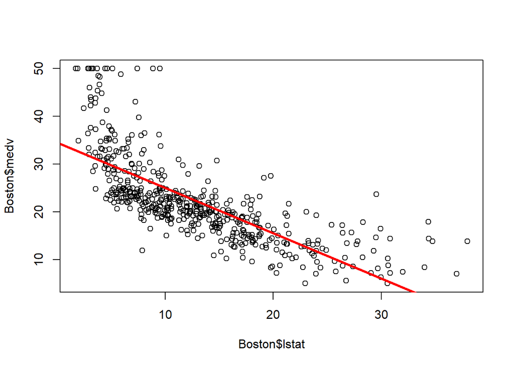

```r
plot(Boston$lstat, Boston$medv)
abline(lm.fit)
abline(lm.fit, lwd=3, col="red")
```

## Diagnostic plots

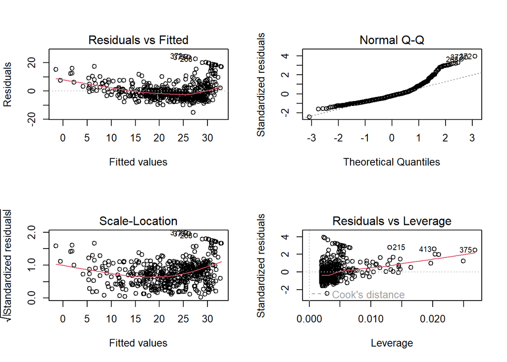

```r
par(mfrow=c(2,2))
plot(lm.fit)
```

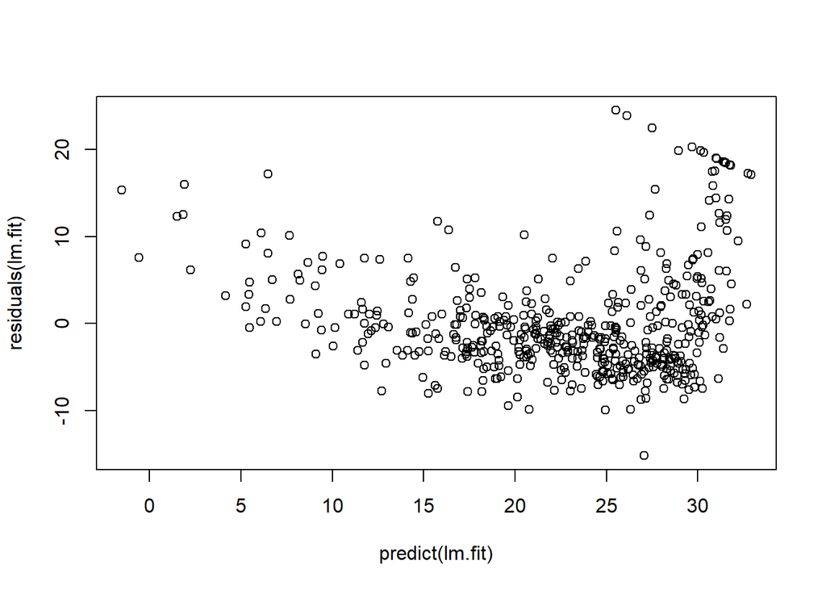

```r
plot(predict(lm.fit), residuals(lm.fit))
```

### Studentized residuals

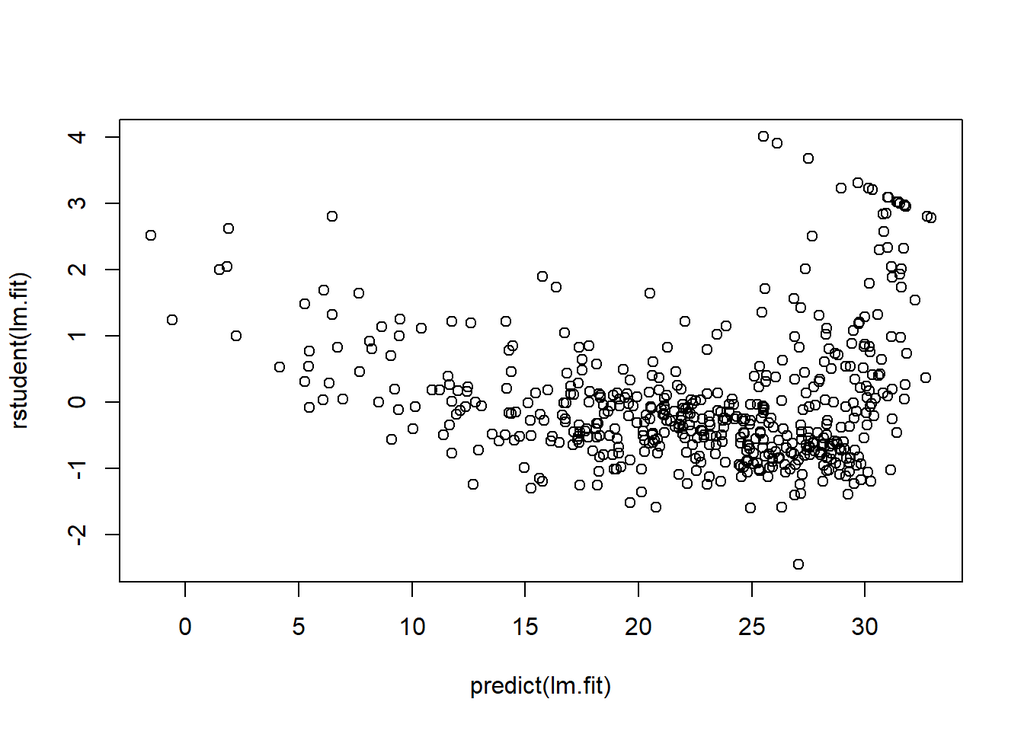

```r
plot(predict(lm.fit), rstudent(lm.fit))
```

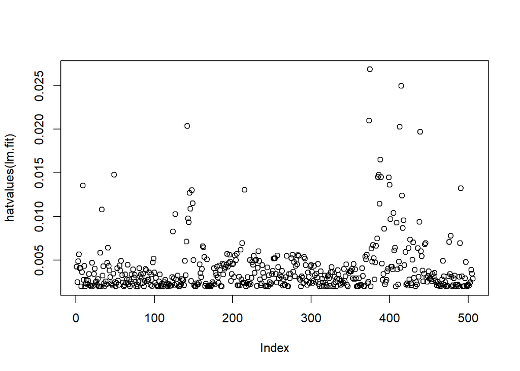

```r
plot(hatvalues(lm.fit))
```

```r
which.max(hatvalues(lm.fit))
```

```
## 375
## 375
```

Let’s say we have 2 populations of n = 100 elements. A population has a parameter that has a distribution over the population of N(90,2). If we apply X1 quantity of treatment A, effect? If we apply x2 quantity of treatment A, effect?

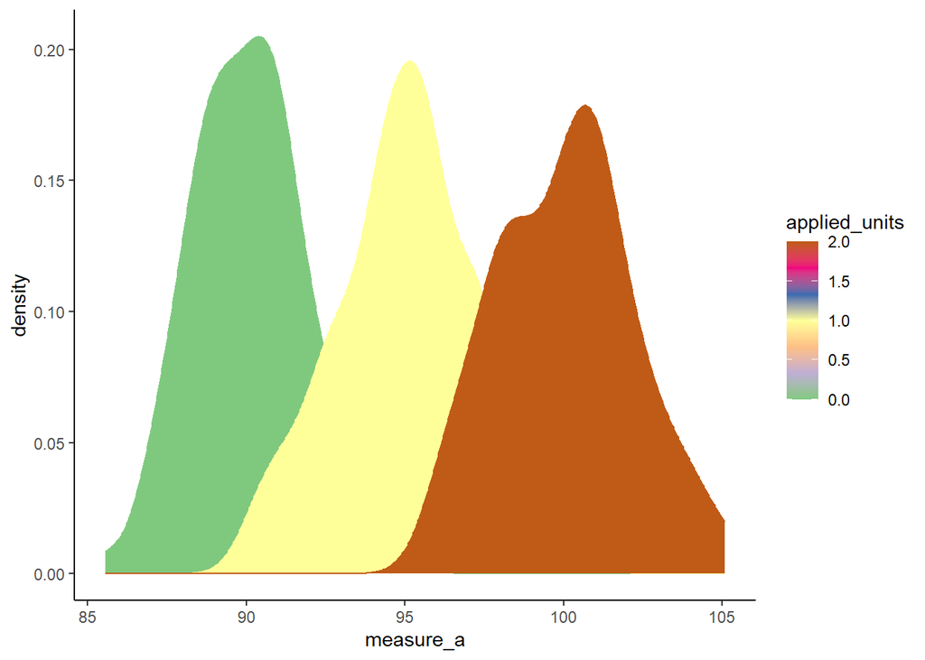

```r
gen_pop = rnorm(100, 90, 2)
df_gen_pop = data.frame("measure_a" = gen_pop, "applied_units" = rep(0,100))
# now let's say treatment adds 5 + error for each unit, where error is standard N(0,1)
treated_1_unit = rnorm(100, 90, 2) + 1 * 5 + rnorm(100, 0, 1)
df_treat1 = data.frame("measure_a" = treated_1_unit, "applied_units" = rep(1,100))

treated_2_unit = rnorm(100, 90, 2) + 2 * 5 + rnorm(100, 0,1)
df_treat2 = data.frame("measure_a" = treated_2_unit, "applied_units" = rep(2,100))

final_df = rbind(df_gen_pop, df_treat1)
final_df = rbind(final_df, df_treat2)

#library(ggplot2)

ggplot(final_df) +
  aes(
    x = measure_a,
    fill = applied_units,
    colour = applied_units,
    group = applied_units
  ) +
  geom_density(adjust = 1L) +
  scale_fill_distiller(palette = "Accent", direction = 1) +
  scale_color_distiller(palette = "Accent", direction = 1) +
  theme_classic()
```

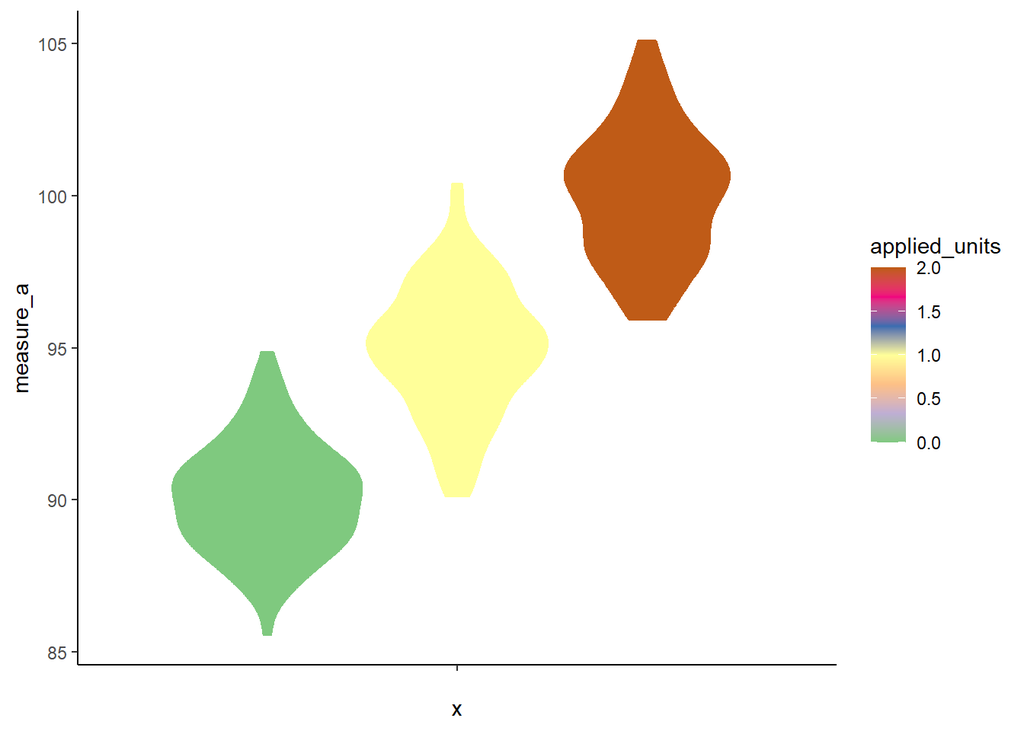

```r
ggplot(final_df) +
  aes(
    x = "",
    y = measure_a,
    fill = applied_units,
    colour = applied_units,
    group = applied_units
  ) +
  geom_violin(adjust = 1L, scale = "area") +
  scale_fill_distiller(palette = "Accent", direction = 1) +
  scale_color_distiller(palette = "Accent", direction = 1) +
  theme_classic()
```

```r
model = lm(measure_a ~ applied_units, data=final_df)
summary(model)
```

```
##
## Call:
## lm(formula = measure_a ~ applied_units, data = final_df)
##
## Residuals:
##     Min      1Q  Median      3Q     Max
## -4.9145 -1.3904  0.0754  1.2403  5.3493
##
## Coefficients:
##               Estimate Std. Error t value Pr(>|t|)
## (Intercept)    90.0577     0.1845  488.16   <2e-16 ***
## applied_units   4.9800     0.1429   34.85   <2e-16 ***
## ---
## Signif. codes:  0 '***' 0.001 '**' 0.01 '*' 0.05 '.' 0.1 ' ' 1
##
## Residual standard error: 2.021 on 298 degrees of freedom
## Multiple R-squared:  0.803,  Adjusted R-squared:  0.8023
## F-statistic:  1214 on 1 and 298 DF,  p-value: < 2.2e-16
```

```r
# coefficients
confint(model)
```

```
##                   2.5 %    97.5 %
## (Intercept)   89.694598 90.420712
## applied_units  4.698757  5.261203
```

## Multiple linear regression

```r
lm.fit <- lm(medv ~ lstat + age, data=Boston)

summary(lm.fit)
```

```
##
## Call:
## lm(formula = medv ~ lstat + age, data = Boston)
##
## Residuals:
##     Min      1Q  Median      3Q     Max
## -15.981  -3.978  -1.283   1.968  23.158
##
## Coefficients:
##             Estimate Std. Error t value Pr(>|t|)
## (Intercept) 33.22276    0.73085  45.458  < 2e-16 ***
## lstat       -1.03207    0.04819 -21.416  < 2e-16 ***
## age          0.03454    0.01223   2.826  0.00491 **
## ---
## Signif. codes:  0 '***' 0.001 '**' 0.01 '*' 0.05 '.' 0.1 ' ' 1
##
## Residual standard error: 6.173 on 503 degrees of freedom
## Multiple R-squared:  0.5513, Adjusted R-squared:  0.5495
## F-statistic:   309 on 2 and 503 DF,  p-value: < 2.2e-16
```

```r
lm.fit <- update(lm.fit, ~ . - age)

summary(lm.fit)
```

```
##
## Call:
## lm(formula = medv ~ lstat, data = Boston)
##
## Residuals:
##     Min      1Q  Median      3Q     Max
## -15.168  -3.990  -1.318   2.034  24.500
##
## Coefficients:
##             Estimate Std. Error t value Pr(>|t|)
## (Intercept) 34.55384    0.56263   61.41   <2e-16 ***
## lstat       -0.95005    0.03873  -24.53   <2e-16 ***
## ---
## Signif. codes:  0 '***' 0.001 '**' 0.01 '*' 0.05 '.' 0.1 ' ' 1
##
## Residual standard error: 6.216 on 504 degrees of freedom
## Multiple R-squared:  0.5441, Adjusted R-squared:  0.5432
## F-statistic: 601.6 on 1 and 504 DF,  p-value: < 2.2e-16
```

### More variables

Sometimes it’s easier to get a full model and just prune it with the Akaike criteria (AIC)

[output not shown]

[output cut: 2066 more lines]

[output not shown]

```
##
## Call:
## lm(formula = medv ~ crim + zn + indus + chas + nox + rm + age +
##     dis + rad + tax + ptratio + lstat + crim:zn + crim:chas +
##     crim:nox + crim:rm + crim:age + crim:rad + crim:tax + crim:ptratio +
##     crim:lstat + zn:dis + zn:tax + zn:lstat + indus:nox + indus:rm +
##     chas:nox + chas:rm + chas:age + chas:ptratio + chas:lstat +
##     nox:age + nox:ptratio + nox:lstat + rm:age + rm:tax + rm:ptratio +
##     rm:lstat + age:dis + age:rad + age:ptratio + age:lstat +
##     dis:tax + dis:lstat + rad:lstat + tax:ptratio + tax:lstat,
##     data = Boston)
##
## Residuals:
##     Min      1Q  Median      3Q     Max
## -8.6705 -1.6207 -0.0224  1.4123 19.7426
##
## Coefficients:
##                Estimate Std. Error t value Pr(>|t|)
## (Intercept)  -1.736e+02  2.203e+01  -7.880 2.40e-14 ***
## crim         -1.441e+01  5.261e+00  -2.739 0.006407 **
## zn           -1.404e-01  4.677e-02  -3.003 0.002819 **
## indus        -3.569e+00  6.078e-01  -5.873 8.23e-09 ***
## chas          6.344e+01  1.170e+01   5.422 9.56e-08 ***
## nox           6.842e+01  2.907e+01   2.354 0.019012 *
## rm            3.057e+01  2.238e+00  13.662  < 2e-16 ***
## age           1.055e+00  1.688e-01   6.247 9.60e-10 ***
## dis          -5.483e-02  5.717e-01  -0.096 0.923629
## rad          -1.259e-01  1.625e-01  -0.775 0.438882
## tax           1.041e-01  3.421e-02   3.045 0.002464 **
## ptratio       3.982e+00  1.171e+00   3.399 0.000734 ***
## lstat         1.598e+00  4.054e-01   3.943 9.31e-05 ***
## crim:zn       2.009e-01  1.147e-01   1.750 0.080702 .
## crim:chas     2.373e+00  3.969e-01   5.979 4.52e-09 ***
## crim:nox     -2.330e+00  6.958e-01  -3.349 0.000877 ***
## crim:rm       2.354e-01  3.895e-02   6.045 3.11e-09 ***
## crim:age      5.450e-03  2.846e-03   1.915 0.056103 .
## crim:rad     -3.959e-01  1.642e-01  -2.411 0.016305 *
## crim:tax      1.969e-02  9.539e-03   2.064 0.039561 *
## crim:ptratio  4.742e-01  2.051e-01   2.312 0.021230 *
## crim:lstat    3.366e-02  5.097e-03   6.604 1.11e-10 ***
```

[output cut: 17 more lines]

```
## age:dis      -1.680e-02  6.531e-03  -2.572 0.010412 *
## age:rad       9.679e-03  1.876e-03   5.158 3.71e-07 ***
## age:ptratio  -1.051e-02  4.552e-03  -2.308 0.021453 *
## age:lstat    -5.425e-03  1.606e-03  -3.378 0.000791 ***
## dis:tax      -3.864e-03  1.290e-03  -2.995 0.002893 **
## dis:lstat     1.015e-01  3.110e-02   3.263 0.001183 **
## rad:lstat    -2.053e-02  7.338e-03  -2.798 0.005354 **
## tax:ptratio   4.263e-03  1.453e-03   2.934 0.003518 **
## tax:lstat    -1.816e-03  4.085e-04  -4.447 1.10e-05 ***
## ---
## Signif. codes:  0 '***' 0.001 '**' 0.01 '*' 0.05 '.' 0.1 ' ' 1
##
## Residual standard error: 2.894 on 458 degrees of freedom
## Multiple R-squared:  0.9102, Adjusted R-squared:  0.901
## F-statistic: 98.78 on 47 and 458 DF,  p-value: < 2.2e-16
```

```r
summary(pruned_model)
```

```
##
## Call:
## lm(formula = medv ~ crim + zn + indus + chas + nox + rm + age +
##     dis + rad + tax + ptratio + lstat + crim:zn + crim:chas +
##     crim:nox + crim:rm + crim:age + crim:rad + crim:tax + crim:ptratio +
##     crim:lstat + zn:dis + zn:tax + zn:lstat + indus:nox + indus:rm +
##     chas:nox + chas:rm + chas:age + chas:ptratio + chas:lstat +
##     nox:age + nox:ptratio + nox:lstat + rm:age + rm:tax + rm:ptratio +
##     rm:lstat + age:dis + age:rad + age:ptratio + age:lstat +
##     dis:tax + dis:lstat + rad:lstat + tax:ptratio + tax:lstat,
##     data = Boston)
##
## Residuals:
##     Min      1Q  Median      3Q     Max
## -8.6705 -1.6207 -0.0224  1.4123 19.7426
##
## Coefficients:
##                Estimate Std. Error t value Pr(>|t|)
## (Intercept)  -1.736e+02  2.203e+01  -7.880 2.40e-14 ***
## crim         -1.441e+01  5.261e+00  -2.739 0.006407 **
## zn           -1.404e-01  4.677e-02  -3.003 0.002819 **
## indus        -3.569e+00  6.078e-01  -5.873 8.23e-09 ***
## chas          6.344e+01  1.170e+01   5.422 9.56e-08 ***
## nox           6.842e+01  2.907e+01   2.354 0.019012 *
## rm            3.057e+01  2.238e+00  13.662  < 2e-16 ***
## age           1.055e+00  1.688e-01   6.247 9.60e-10 ***
## dis          -5.483e-02  5.717e-01  -0.096 0.923629
## rad          -1.259e-01  1.625e-01  -0.775 0.438882
## tax           1.041e-01  3.421e-02   3.045 0.002464 **
## ptratio       3.982e+00  1.171e+00   3.399 0.000734 ***
## lstat         1.598e+00  4.054e-01   3.943 9.31e-05 ***
## crim:zn       2.009e-01  1.147e-01   1.750 0.080702 .
## crim:chas     2.373e+00  3.969e-01   5.979 4.52e-09 ***
## crim:nox     -2.330e+00  6.958e-01  -3.349 0.000877 ***
## crim:rm       2.354e-01  3.895e-02   6.045 3.11e-09 ***
## crim:age      5.450e-03  2.846e-03   1.915 0.056103 .
## crim:rad     -3.959e-01  1.642e-01  -2.411 0.016305 *
## crim:tax      1.969e-02  9.539e-03   2.064 0.039561 *
## crim:ptratio  4.742e-01  2.051e-01   2.312 0.021230 *
## crim:lstat    3.366e-02  5.097e-03   6.604 1.11e-10 ***
```

[output cut: 17 more lines]

```
## age:dis      -1.680e-02  6.531e-03  -2.572 0.010412 *
## age:rad       9.679e-03  1.876e-03   5.158 3.71e-07 ***
## age:ptratio  -1.051e-02  4.552e-03  -2.308 0.021453 *
## age:lstat    -5.425e-03  1.606e-03  -3.378 0.000791 ***
## dis:tax      -3.864e-03  1.290e-03  -2.995 0.002893 **
## dis:lstat     1.015e-01  3.110e-02   3.263 0.001183 **
## rad:lstat    -2.053e-02  7.338e-03  -2.798 0.005354 **
## tax:ptratio   4.263e-03  1.453e-03   2.934 0.003518 **
## tax:lstat    -1.816e-03  4.085e-04  -4.447 1.10e-05 ***
## ---
## Signif. codes:  0 '***' 0.001 '**' 0.01 '*' 0.05 '.' 0.1 ' ' 1
##
## Residual standard error: 2.894 on 458 degrees of freedom
## Multiple R-squared:  0.9102, Adjusted R-squared:  0.901
## F-statistic: 98.78 on 47 and 458 DF,  p-value: < 2.2e-16
```

### Anova test

anova performs a hypothesis test comparing the 2 models. Null hypothesis is that the two models fit the data equally well, the alternative hypothesis is that the full model is superior.

```r
first_model <- lm(medv ~ lstat + age, data=Boston)
anova(first_model, lm.fit)
```

```
## Analysis of Variance Table
##
## Model 1: medv ~ lstat + age
## Model 2: medv ~ crim + zn + indus + chas + nox + rm + age + dis + rad +
##     tax + ptratio + lstat + (crim + zn + indus + chas + nox +
##     rm + age + dis + rad + tax + ptratio + lstat) * (crim + zn +
##     indus + chas + nox + rm + age + dis + rad + tax + ptratio +
##     lstat)
##   Res.Df     RSS Df Sum of Sq      F    Pr(>F)
## 1    503 19168.1
## 2    427  3732.5 76     15436 23.235 < 2.2e-16 ***
## ---
## Signif. codes:  0 '***' 0.001 '**' 0.01 '*' 0.05 '.' 0.1 ' ' 1
```

### Cualitative predictors

```r
head(Carseats)
```

```
##   Sales CompPrice Income Advertising Population Price ShelveLoc Age Education
## 1  9.50       138     73          11        276   120       Bad  42        17
## 2 11.22       111     48          16        260    83      Good  65        10
## 3 10.06       113     35          10        269    80    Medium  59        12
## 4  7.40       117    100           4        466    97    Medium  55        14
## 5  4.15       141     64           3        340   128       Bad  38        13
## 6 10.81       124    113          13        501    72       Bad  78        16
##   Urban  US
## 1   Yes Yes
## 2   Yes Yes
## 3   Yes Yes
## 4   Yes Yes
## 5   Yes  No
## 6    No Yes
```

```r
carseats_model_1 <- lm(Sales ~ . + Income:Advertising + Price:Age, data=Carseats)
```

# Classification methods

## Two classes

A discriminant function is a function that takes a vector of inputs x and tells us if it belongs to Class $C_1$ or $C_2$. The form of the function is $y(x) = w^T x + w_0$, where $w^T$ is the weights vector and x is the features matrix.

The decision boundary is defined by the relation $y(x) = 0$ which corresponds to a $D-1$ dimensional hyperplan within a D-dimensional input space.

## Stock Market Data

```r
names(Smarket)
```

```
## [1] "Year"      "Lag1"      "Lag2"      "Lag3"      "Lag4"      "Lag5"
## [7] "Volume"    "Today"     "Direction"
```

```r
dim(Smarket)
```

```
## [1] 1250    9
```

```r
summary(Smarket)
```

```
##       Year           Lag1                Lag2                Lag3
##  Min.   :2001   Min.   :-4.922000   Min.   :-4.922000   Min.   :-4.922000
##  1st Qu.:2002   1st Qu.:-0.639500   1st Qu.:-0.639500   1st Qu.:-0.640000
##  Median :2003   Median : 0.039000   Median : 0.039000   Median : 0.038500
##  Mean   :2003   Mean   : 0.003834   Mean   : 0.003919   Mean   : 0.001716
##  3rd Qu.:2004   3rd Qu.: 0.596750   3rd Qu.: 0.596750   3rd Qu.: 0.596750
##  Max.   :2005   Max.   : 5.733000   Max.   : 5.733000   Max.   : 5.733000
##       Lag4                Lag5              Volume           Today
##  Min.   :-4.922000   Min.   :-4.92200   Min.   :0.3561   Min.   :-4.922000
##  1st Qu.:-0.640000   1st Qu.:-0.64000   1st Qu.:1.2574   1st Qu.:-0.639500
##  Median : 0.038500   Median : 0.03850   Median :1.4229   Median : 0.038500
##  Mean   : 0.001636   Mean   : 0.00561   Mean   :1.4783   Mean   : 0.003138
##  3rd Qu.: 0.596750   3rd Qu.: 0.59700   3rd Qu.:1.6417   3rd Qu.: 0.596750
##  Max.   : 5.733000   Max.   : 5.73300   Max.   :3.1525   Max.   : 5.733000
##  Direction
##  Down:602
##  Up  :648
##
##
##
##
```

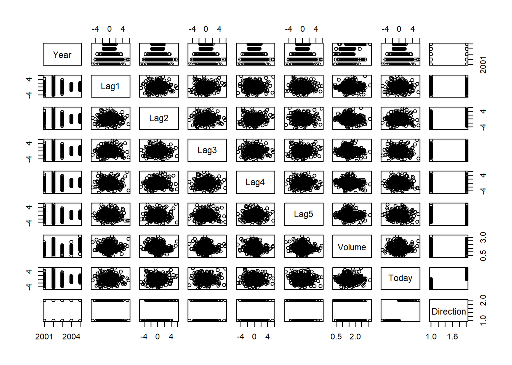

```r
pairs(Smarket)
```

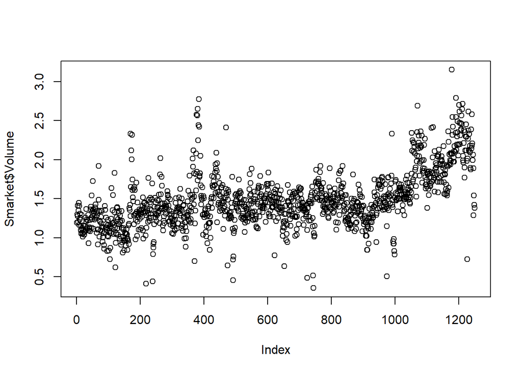

```r
plot(Smarket$Volume)
```

## Logistic regression

Logistic regression is equivalent to linear regression in the fact that we also model a prediction as a function of a sum of terms.

For this it is used the logistic function
$$p(x) = \dfrac{e^{\beta_0 + \beta_1 x}} {{1 +
e^{\beta_0 + \beta_1 x}}}$$
Manipulating a bit
$$\dfrac{p(x)}{1-p(x)} = e^{\beta_0 + \beta_1 x}$$
The left hand is called ODDS, takes values between 0 and $\inf$. If p(x) = 0.8, then the odds is 0.8/0.2. “On average, nine out of ten people (p(x) = 0.9 => 0.9/0.1 = odds) with an odds of 9 will default” Making the log of both sides
$$log \left ( \dfrac{p(x)}{1-p(x)} \right ) =
\beta_0 + \beta_1 x$$
So, coefficients here play the following role. An increase in one unit in $\beta_1$ increases the log odds by $value(\beta_1)$

We will fit a logistic regression to predict with Lag1 … Lag5 Use glm() with arg family = binomial

```r
glm.fits <- glm(Direction ~ Lag1 + Lag2 + Lag3 + Lag4 + Lag5 + Volume, data=Smarket, family=binomial)
summary(glm.fits)
```

```
##
## Call:
## glm(formula = Direction ~ Lag1 + Lag2 + Lag3 + Lag4 + Lag5 +
##     Volume, family = binomial, data = Smarket)
##
## Deviance Residuals:
##    Min      1Q  Median      3Q     Max
## -1.446  -1.203   1.065   1.145   1.326
##
## Coefficients:
##              Estimate Std. Error z value Pr(>|z|)
## (Intercept) -0.126000   0.240736  -0.523    0.601
## Lag1        -0.073074   0.050167  -1.457    0.145
## Lag2        -0.042301   0.050086  -0.845    0.398
## Lag3         0.011085   0.049939   0.222    0.824
## Lag4         0.009359   0.049974   0.187    0.851
## Lag5         0.010313   0.049511   0.208    0.835
## Volume       0.135441   0.158360   0.855    0.392
##
## (Dispersion parameter for binomial family taken to be 1)
##
##     Null deviance: 1731.2  on 1249  degrees of freedom
## Residual deviance: 1727.6  on 1243  degrees of freedom
## AIC: 1741.6
##
## Number of Fisher Scoring iterations: 3
```

```r
coef(glm.fits)
```

```
##  (Intercept)         Lag1         Lag2         Lag3         Lag4         Lag5
## -0.126000257 -0.073073746 -0.042301344  0.011085108  0.009358938  0.010313068
##       Volume
##  0.135440659
```

Coefficient for Lag 1 is -0.073. This means that 1 unit increase in Lag1 is associated with an increase in the log odds of Direction by -0.073 units.

```r
# access some aspects of summary
summary(glm.fits)$coef
```

```
##                 Estimate Std. Error    z value  Pr(>|z|)
## (Intercept) -0.126000257 0.24073574 -0.5233966 0.6006983
## Lag1        -0.073073746 0.05016739 -1.4565986 0.1452272
## Lag2        -0.042301344 0.05008605 -0.8445733 0.3983491
## Lag3         0.011085108 0.04993854  0.2219750 0.8243333
## Lag4         0.009358938 0.04997413  0.1872757 0.8514445
## Lag5         0.010313068 0.04951146  0.2082966 0.8349974
## Volume       0.135440659 0.15835970  0.8552723 0.3924004
```

```r
summary(glm.fits)$coef[,4]
```

```
## (Intercept)        Lag1        Lag2        Lag3        Lag4        Lag5
##   0.6006983   0.1452272   0.3983491   0.8243333   0.8514445   0.8349974
##      Volume
##   0.3924004
```

Make judgements with data

```r
glm.probs <- predict(glm.fits, type="response")
glm.probs[1:10]
```

```
##         1         2         3         4         5         6         7         8
## 0.5070841 0.4814679 0.4811388 0.5152224 0.5107812 0.5069565 0.4926509 0.5092292
##         9        10
## 0.5176135 0.4888378
```

```r
contrasts(Smarket$Direction)
```

```
##      Up
## Down  0
## Up    1
```

```r
# R will try to create a dummy variable
glm.pred <- rep("Down", 1250) # create a new variable with Down
glm.pred[glm.probs > .5] = "Up" # comparing both vectors, when glm.probs[i] > .5, glm.pred[i] = Up
table(glm.pred, Smarket$Direction) # create a confusion matrix. Diagonal = correct, Off-diagonal = incorrect
```

```
##
## glm.pred Down  Up
##     Down  145 141
##     Up    457 507
```

```r
# when predicted Down, 145 were correctly Down, but 141 predicted Down and should be Up

# we can get the precision of our prediction
mean(glm.pred == Smarket$Direction)
```

```
## [1] 0.5216
```

```r
# error rate is
1 - mean(glm.pred == Smarket$Direction)
```

```
## [1] 0.4784
```

```r
# prepare a train data set out of the big one
train <- Smarket$Year < 2005
Smarket.2005 <- Smarket[!train, ]
dim(Smarket.2005)
```

```
## [1] 252   9
```

```r
Smarket.Direction.2005 <- Smarket$Direction[!train]

glm.fits <- glm( Direction ~ Lag1 + Lag2 + Lag3 + Lag4 + Lag5 + Volume,
                 data = Smarket, family = binomial, subset = train)
summary(glm.fits)
```

```
##
## Call:
## glm(formula = Direction ~ Lag1 + Lag2 + Lag3 + Lag4 + Lag5 +
##     Volume, family = binomial, data = Smarket, subset = train)
##
## Deviance Residuals:
##    Min      1Q  Median      3Q     Max
## -1.302  -1.190   1.079   1.160   1.350
##
## Coefficients:
##              Estimate Std. Error z value Pr(>|z|)
## (Intercept)  0.191213   0.333690   0.573    0.567
## Lag1        -0.054178   0.051785  -1.046    0.295
## Lag2        -0.045805   0.051797  -0.884    0.377
## Lag3         0.007200   0.051644   0.139    0.889
## Lag4         0.006441   0.051706   0.125    0.901
## Lag5        -0.004223   0.051138  -0.083    0.934
## Volume      -0.116257   0.239618  -0.485    0.628
##
## (Dispersion parameter for binomial family taken to be 1)
##
##     Null deviance: 1383.3  on 997  degrees of freedom
## Residual deviance: 1381.1  on 991  degrees of freedom
## AIC: 1395.1
##
## Number of Fisher Scoring iterations: 3
```

```r
coef(glm.fits)
```

```
##  (Intercept)         Lag1         Lag2         Lag3         Lag4         Lag5
##  0.191212621 -0.054178292 -0.045805334  0.007200118  0.006440875 -0.004222672
##       Volume
## -0.116256960
```

```r
glm.probs <- predict(glm.fits, Smarket.2005, type="response")
glm.pred <- rep("Down", 252)
glm.pred[glm.probs > .5] <- "Up"
table(glm.pred, Smarket.Direction.2005)
```

```
##         Smarket.Direction.2005
## glm.pred Down Up
##     Down   77 97
##     Up     34 44
```

```r
mean(glm.pred == Smarket.Direction.2005) # accuracy compared with Direction 2005
```

```
## [1] 0.4801587
```

```r
mean(glm.pred != Smarket.Direction.2005) # accuracy in others
```

```
## [1] 0.5198413
```

## Linear Discriminant Analysis

```r
lda.fit <- lda(Direction ~ Lag1 + Lag2, data=Smarket, subset=train)
lda.fit
```

```
## Call:
## lda(Direction ~ Lag1 + Lag2, data = Smarket, subset = train)
##
## Prior probabilities of groups:
##     Down       Up
## 0.491984 0.508016
##
## Group means:
##             Lag1        Lag2
## Down  0.04279022  0.03389409
## Up   -0.03954635 -0.03132544
##
## Coefficients of linear discriminants:
##             LD1
## Lag1 -0.6420190
## Lag2 -0.5135293
```

```r
summary(lda.fit)
```

```
##         Length Class  Mode
## prior   2      -none- numeric
## counts  2      -none- numeric
## means   4      -none- numeric
## scaling 2      -none- numeric
## lev     2      -none- character
## svd     1      -none- numeric
## N       1      -none- numeric
## call    4      -none- call
## terms   3      terms  call
## xlevels 0      -none- list
```

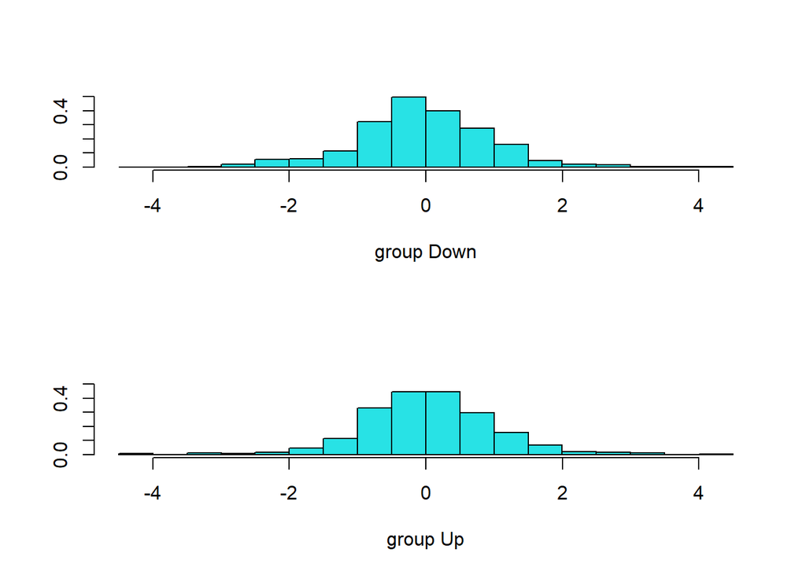

```r
plot(lda.fit)
```

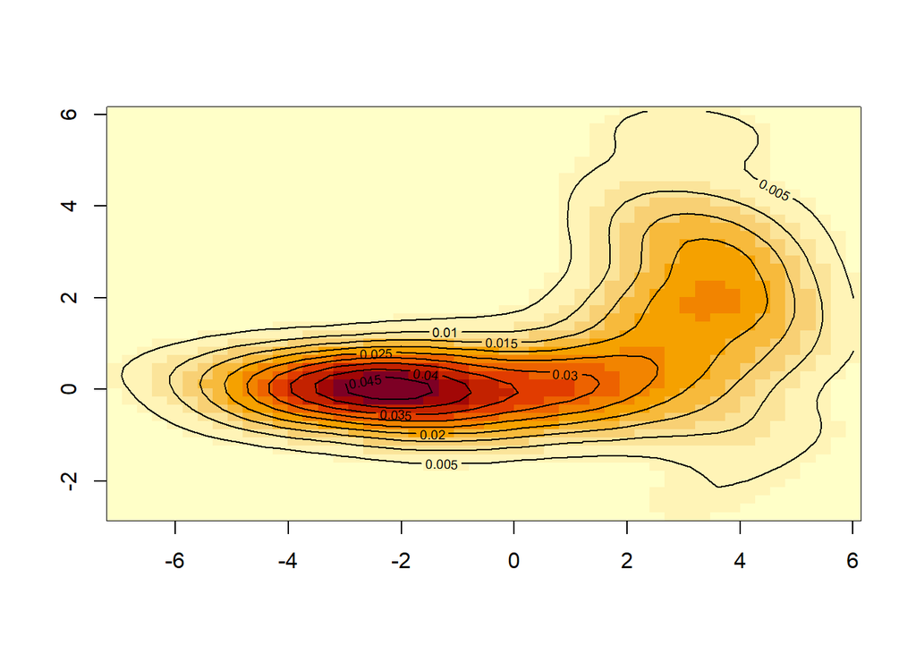

```r
# creamos 2 grupos con diferente distribucion de 2 variables (x,y)
grupo1_x = rnorm(100, mean=-2, sd=2)
grupo1_y = rnorm(100, mean=0, sd=0.5)
grupo2_x = rnorm(100, mean=3, sd=1)
grupo2_y = rnorm(100, mean=2, sd=2)
ndf = data.frame(x = c(grupo1_x, grupo2_x), y = c(grupo1_y, grupo2_y), group = c(rep(1, 100), rep(2, 100)))
ndf$group = factor(ndf$group)

bin.kde = kde2d(ndf$x, ndf$y, n=50)
image(bin.kde)
contour(bin.kde, add=T)
```

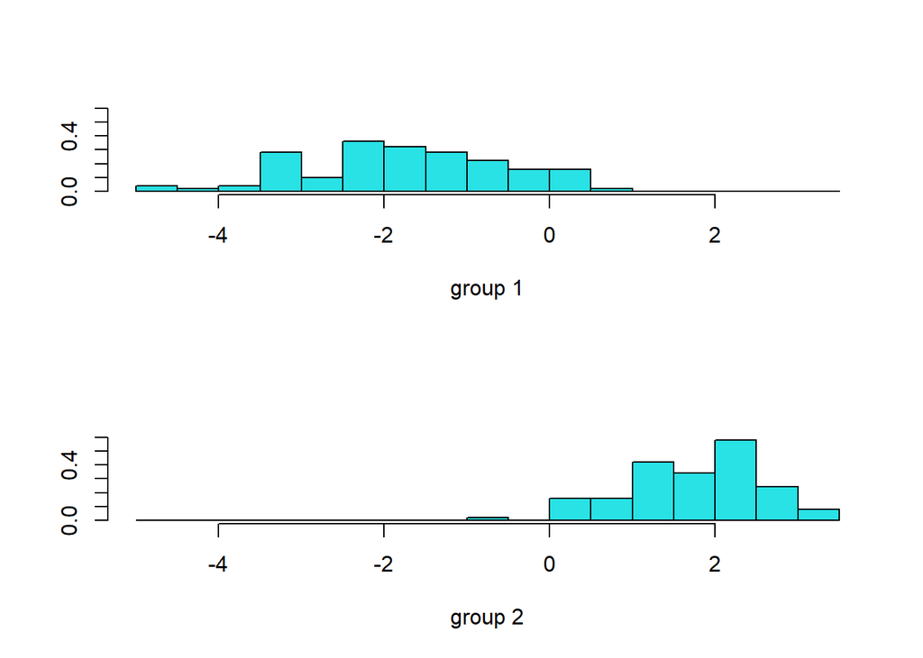

```r
lda.fit2 = lda(group ~ x + y, data=ndf)
plot(lda.fit2)
```

```r
lda.pred = predict(lda.fit2)
lda.class = lda.pred$class
table(lda.class, ndf$group)
```

```
##
## lda.class  1  2
##         1 91  1
##         2  9 99
```

```r
mean(lda.class == ndf$group) # precision
```

```
## [1] 0.95
```

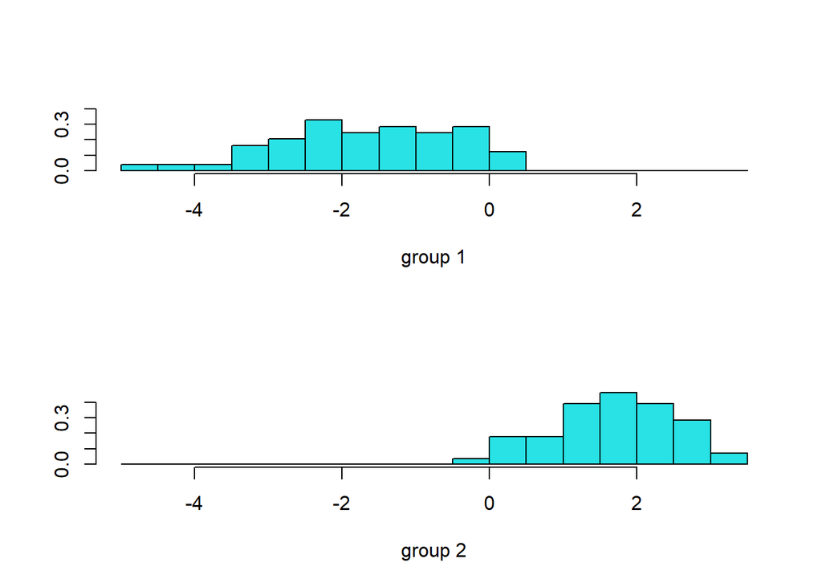

```r
# ahora usamos un subset
train = sample(c(T,F), 200, replace=T, prob=c(0.5,0.5))
lda.fit3 = lda(group ~ x + y, data=ndf, subset=train)
plot(lda.fit3)
```

```r
lda.pred3 = predict(lda.fit3, ndf[!train,])
lda.class3 = lda.pred3$class
table(lda.class3, ndf$group[!train])
```

```
##
## lda.class3  1  2
##          1 43  0
##          2  8 44
```

```r
mean(lda.class3 == ndf$group[!train])
```

```
## [1] 0.9157895
```

### 10-fold CV LDA

```r
#library(caret)

fitControl <- trainControl(method = "cv", number = 10)

fit.lda.cv <- train(group ~ x + y,
             method     = "lda",
             #tuneGrid   = expand.grid(k = 1:10),
             preProcess = c("center", "scale"),
             trControl  = fitControl,
             metric     = "Accuracy",
             data       = ndf)
fit.lda.cv
```

```
## Linear Discriminant Analysis
##
## 200 samples
##   2 predictor
##   2 classes: '1', '2'
##
## Pre-processing: centered (2), scaled (2)
## Resampling: Cross-Validated (10 fold)
## Summary of sample sizes: 180, 180, 180, 180, 180, 180, ...
## Resampling results:
##
##   Accuracy  Kappa
##   0.945     0.89
```

```r
#plot(fit.lda.cv)
```

## Quadratic Discriminant analysis

```r
qda.fit <- qda(Direction ~ Lag1 + Lag2, data=Smarket, subset=train)
qda.fit
```

```
## Call:
## qda(Direction ~ Lag1 + Lag2, data = Smarket, subset = train)
##
## Prior probabilities of groups:
##      Down        Up
## 0.4862805 0.5137195
##
## Group means:
##             Lag1        Lag2
## Down  0.02705016  0.10354232
## Up   -0.05500297 -0.02237092
```

```r
summary(qda.fit)
```

```
##         Length Class  Mode
## prior   2      -none- numeric
## counts  2      -none- numeric
## means   4      -none- numeric
## scaling 8      -none- numeric
## ldet    2      -none- numeric
## lev     2      -none- character
## N       1      -none- numeric
## call    4      -none- call
## terms   3      terms  call
## xlevels 0      -none- list
```

```r
# get the predictions
qda.class <- predict(qda.fit, Smarket.2005)$class
table(qda.class, Smarket.Direction.2005)
```

```
##          Smarket.Direction.2005
## qda.class Down  Up
##      Down    9   6
##      Up    102 135
```

```r
mean(qda.class == Smarket.Direction.2005)
```

```
## [1] 0.5714286
```

## Naive Bayes

```r
#library(e1071)
nb.fit <- naiveBayes(Direction ~ Lag1 + Lag2, data=Smarket, subset=train)
nb.fit
```

```
##
## Naive Bayes Classifier for Discrete Predictors
##
## Call:
## naiveBayes.default(x = X, y = Y, laplace = laplace)
##
## A-priori probabilities:
## Y
##      Down        Up
## 0.4862805 0.5137195
##
## Conditional probabilities:
##       Lag1
## Y             [,1]     [,2]
##   Down  0.02705016 1.189211
##   Up   -0.05500297 1.070744
##
##       Lag2
## Y             [,1]     [,2]
##   Down  0.10354232 1.273979
##   Up   -0.02237092 1.125967
```

```r
summary(nb.fit)
```

```
##           Length Class  Mode
## apriori   2      table  numeric
## tables    2      -none- list
## levels    2      -none- character
## isnumeric 2      -none- logical
## call      4      -none- call
```

```r
head(predict(glm.fits, Smarket.2005, type="response"))
```

```
##       999      1000      1001      1002      1003      1004
## 0.5282195 0.5156688 0.5226521 0.5138543 0.4983345 0.5010912
```

```r
head(predict(nb.fit, Smarket.2005, type="raw"))
```

```
##           Down        Up
## [1,] 0.4274583 0.5725417
## [2,] 0.4268316 0.5731684
## [3,] 0.4352500 0.5647500
## [4,] 0.4313503 0.5686497
## [5,] 0.4329460 0.5670540
## [6,] 0.4368236 0.5631764
```

## KNN (K nearest neighbors)

```r
#library(class)
train.x <- cbind(Smarket$Lag1, Smarket$Lag2)[train,]
test.x <- cbind(Smarket$Lag1, Smarket$Lag2)[!train,]
train.direction <- Smarket$Direction[train]
knn.pred <- knn(train.x, test.x, train.direction, k=1) # knn.pred has predictions for test.x
table(knn.pred, Smarket$Direction[!train])
```

```
##
## knn.pred Down  Up
##     Down  136 147
##     Up    147 164
```

```r
mean(knn.pred == Smarket$Direction[!train]) # check proportion of test.x predictions correct (!train)
```

```
## [1] 0.5050505
```

```r
# we try setting the hyperparameter k to 3
knn.pred <- knn(train.x, test.x, train.direction, k=3)
table(knn.pred, Smarket$Direction[!train])
```

```
##
## knn.pred Down  Up
##     Down  131 161
##     Up    152 150
```

```r
mean(knn.pred == Smarket$Direction[!train])
```

```
## [1] 0.473064
```

Now let’s make a more random data set

```r
train <- sample(c(TRUE, FALSE), nrow(Smarket), replace=TRUE, prob=c(0.7, 0.3)) # 70% for train, 30% for test
train.x <- cbind(Smarket$Lag1, Smarket$Lag2)[train,]
test.x <- cbind(Smarket$Lag1, Smarket$Lag2)[!train,]
train.direction <- Smarket$Direction[train]
knn.pred <- knn(train.x, test.x, train.direction, k=1)
table(knn.pred, Smarket$Direction[!train])
```

```
##
## knn.pred Down Up
##     Down   77 78
##     Up     90 97
```

```r
mean(knn.pred == Smarket$Direction[!train])
```

```
## [1] 0.5087719
```

```r
# we try setting the hyperparameter k to 3
knn.pred <- knn(train.x, test.x, train.direction, k=3)
table(knn.pred, Smarket$Direction[!train])
```

```
##
## knn.pred Down Up
##     Down   78 87
##     Up     89 88
```

```r
mean(knn.pred == Smarket$Direction[!train])
```

```
## [1] 0.4853801
```

When we have variables with high differences in values it can affect the prediction results. A difference of 1000 dolars could be much more signifficant than a difference of 50 years, but speaking in absolute terms the salary will have more impact on predictions due to its scale.

So to prevent this effects we standardize variables

```r
set.seed(1)
standardized.x <- scale(Caravan[,-86]) # get our data set standardized without the 86th column (Purchase)
var(Caravan[,1])
```

```
## [1] 165.0378
```

```r
test <- 1:1000 # divide dataset. We we'll get 1000 values for testing, the rest will be used for training
# well, it's just wrong. better
train <- sample(c(TRUE, FALSE), nrow(Caravan), replace=TRUE, prob=c(0.7, 0.3)) # 70% for train, 30% for test
train.x <- standardized.x[train,]
test.x <- standardized.x[!train,]
train.y <- Caravan$Purchase[train] # train y is Purchase
test.y <- Caravan$Purchase[!train] # in y we put Purchase

knn.pred <- knn(train.x, test.x, train.y, k=1)
mean(test.y == knn.pred) # accuracy of predictions against test datat
```

```
## [1] 0.8826502
```

```r
# success rate
table(knn.pred, test.y)
```

```
##         test.y
## knn.pred   No  Yes
##      No  1562  114
##      Yes   95   10
```

```r
knn.pred <- knn(train.x, test.x, train.y, k=3)
mean(test.y == knn.pred) # accuracy of predictions against test data
```

```
## [1] 0.9213925
```

```r
table(knn.pred, test.y)
```

```
##         test.y
## knn.pred   No  Yes
##      No  1634  117
##      Yes   23    7
```

## Cross Validation KNN

Now use the new dataset created with bivariate data. Use 10 CV-fold to select the hyperparameter K.

```r
library(caret)

fitControl <- trainControl(## 10-fold CV
                           method = "repeatedcv",
                           number = 10,
                           ## repeated ten times
                           repeats = 10)

fit.knn <- train(group ~ x + y,
             method     = "knn",
             tuneGrid   = expand.grid(k = 1:10),
             trControl  = fitControl,
             metric     = "Accuracy",
             data       = ndf)
fit.knn
```

```
## k-Nearest Neighbors
##
## 200 samples
##   2 predictor
##   2 classes: '1', '2'
##
## No pre-processing
## Resampling: Cross-Validated (10 fold, repeated 10 times)
## Summary of sample sizes: 180, 180, 180, 180, 180, 180, ...
## Resampling results across tuning parameters:
##
##   k   Accuracy  Kappa
##    1  0.9370    0.874
##    2  0.9485    0.897
##    3  0.9665    0.933
##    4  0.9630    0.926
##    5  0.9645    0.929
##    6  0.9660    0.932
##    7  0.9660    0.932
##    8  0.9635    0.927
##    9  0.9675    0.935
##   10  0.9630    0.926
##
## Accuracy was used to select the optimal model using the largest value.
## The final value used for the model was k = 9.
```

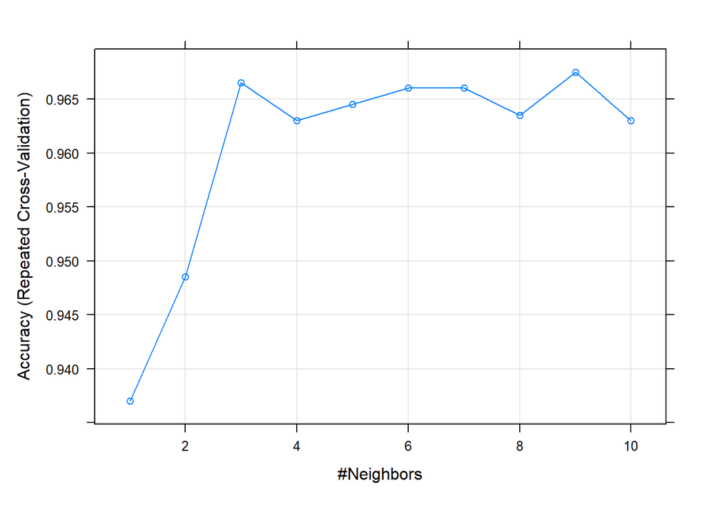

```r
plot(fit.knn)
```